# Lab: Multivariate Analysis

## Turtle PCA

To start we will come back to the turtles data set. First, we need to make sure we understand the basic features of the data and preprocess it in a way that its in the correct “shape” for running the PCA analysis.

**Questions**

1. What are the mean values and standard deviation, of each of the 3 features: length, width and height.
2. Scale the data.
3. Explore the correlations between the 3 variables after scaling the data. What do you see?

```r
#1
apply(turtles[, -1], 2, mean)
```

```
   length     width    height
124.68750  95.43750  46.33333
```

```r
apply(turtles[, -1], 2, sd)
```

```
   length     width    height
20.481602 12.675838  8.392837
```

```r
#2
turtlesc = scale(turtles[, -1])

#3
corrs = cor(turtlesc)
corrs |> round(3)
```

```
       length width height
length  1.000 0.978  0.965
width   0.978 1.000  0.961
height  0.965 0.961  1.000
```

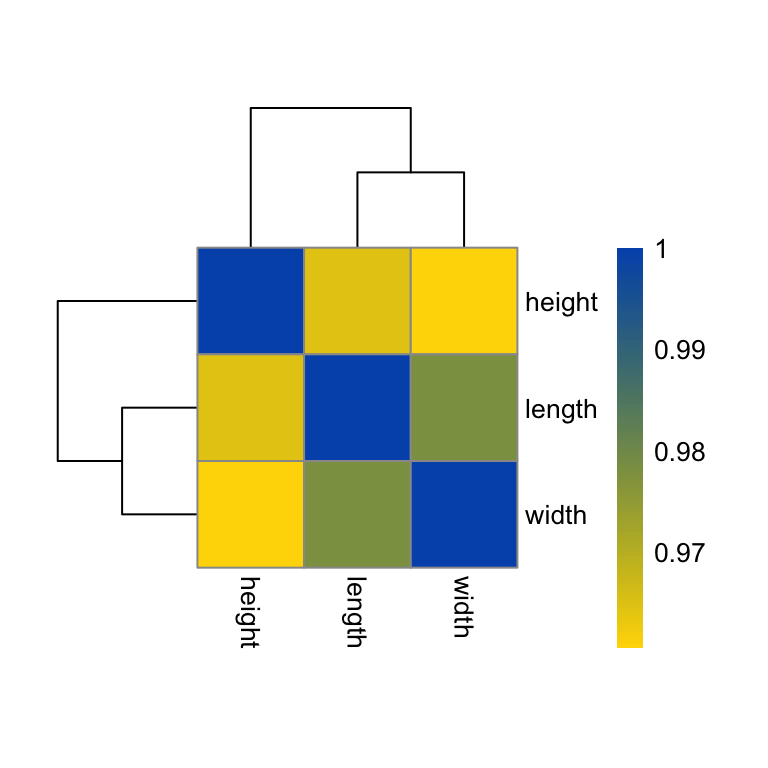

```r
pheatmap(corrs, cellwidth = 40, cellheight = 40, color = mycolors)
```

From the correlations, you see that all 3 variables are strongly correlated. (In the heatmap, note that the color scale already starts with a high value at its lower end.) Hence we expect that the data can be well approximated by a single variable. Let’s do the PCA:

```r
library("factoextra")
pca1 = princomp(turtlesc)
pca1
```

```
Call:
princomp(x = turtlesc)

Standard deviations:
   Comp.1    Comp.2    Comp.3
1.6954576 0.2048201 0.1448180

 3  variables and  48 observations.
```

To look at the relative importance of the principal components, we can look at their variances: the screeplot. The screeplot shows the eigenvalues for the standardized data.

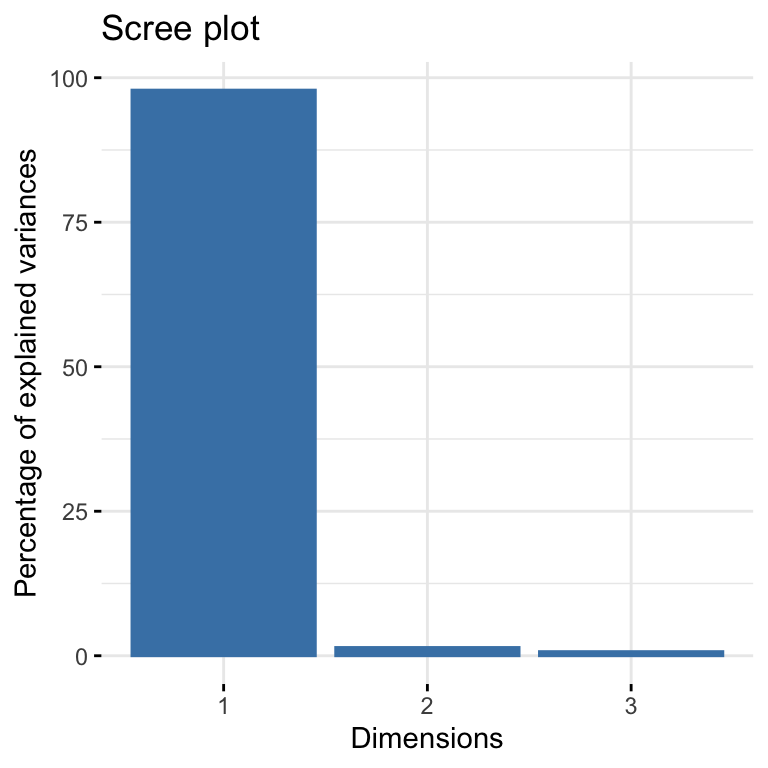

```r
fviz_eig(pca1, geom = "bar", width = 0.4)
```

Note: Here we see one very large component in this case and two very small ones. In this case the data are (almost) one dimensional.

**Questions**

1. What is the percentage of variance explained by the first PC? How can you obtain this value from the pca1 object?
2. How many PCs are you using if you want to project the turtles data set?

```r
#1
summary(pca1)
```

```
Importance of components:
                          Comp.1     Comp.2      Comp.3
Standard deviation     1.6954576 0.20482013 0.144818032
Proportion of Variance 0.9785792 0.01428129 0.007139494
Cumulative Proportion  0.9785792 0.99286051 1.000000000
```

```r
#2
# One PC would be sufficient.
```

Now, lets plot the samples with their PC1 and PC2 coordinates, together with the variables. The representation of both, the samples and the variables is called a biplot.

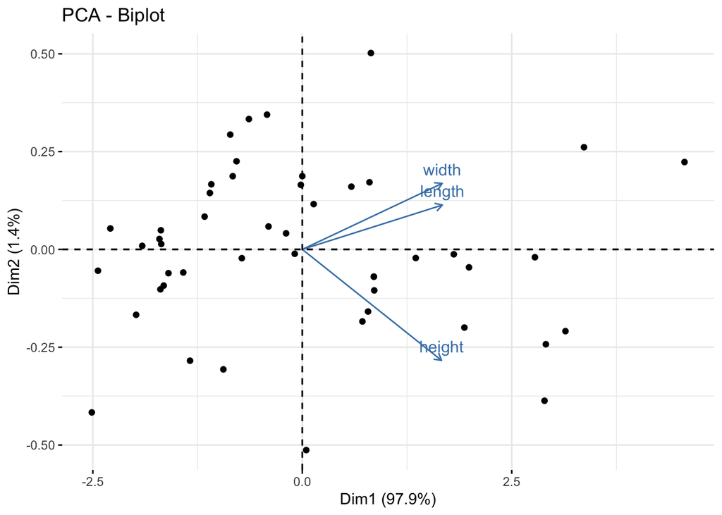

```r
fviz_pca_biplot(pca1, label = "var")
```

**Questions**

1. Can you extend this plotting code to color the female samples differently than the male samples?
2. Did the males or female turtles tend to be larger?

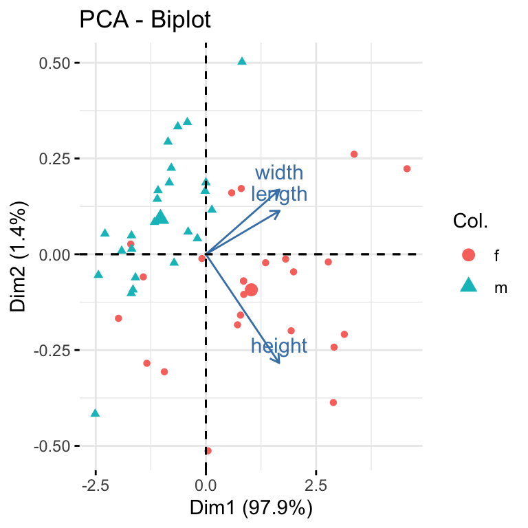

```r
#6
fviz_pca_biplot(pca1, label = "var", col.ind = turtles[,1])
```

```r
#7
# Females
```

## Back to the athletes

Now let us try to run the PCA on a larger data set and interpret the corresponding scree plot. In this case we are using a different library, with a slightly different output of the PCA computation. But the principle is the same.

```r
library("ade4")
# The dudi.pca function by default already centers and scales the data by itself
pca.ath = dudi.pca(athletes, scannf = FALSE)
pca.ath$eig
```

```
 [1] 3.4182381 2.6063931 0.9432964 0.8780212 0.5566267 0.4912275 0.4305952
 [8] 0.3067981 0.2669494 0.1018542
```

**Questions**

1. Just like in the above turtle data set. Can you produce a scree plot?
2. How many PCs are you using if you want to project the athletes data set?
3. Can you plot the samples with their PC1 and PC2 coordinates, together with the variables in a biplot?
4. Can you plot the numbers of the athletes onto the samples. What do you notice about the numbers?

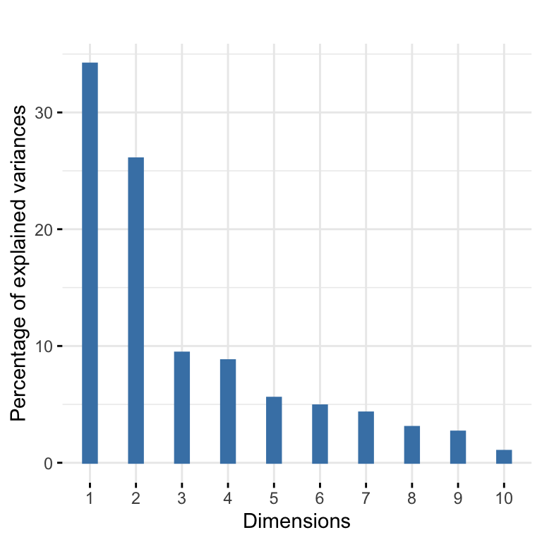

```r
#1
fviz_eig(pca.ath, geom = "bar", bar_width = 0.3) + ggtitle("")
```

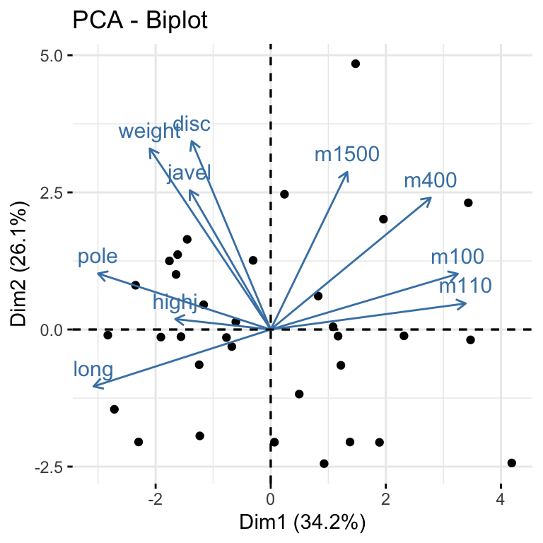

```r
#2
#     Somewhere between 2 and 4

#3
fviz_pca_biplot(pca.ath, label = "var")
```

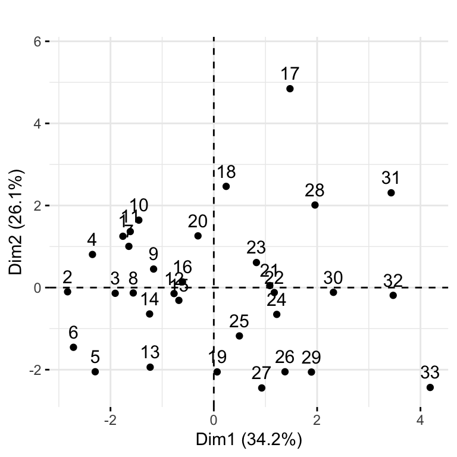

```r
#4
fviz_pca_ind(pca.ath) + ggtitle("") + ylim(c(-2.5, 5.7))
```